# Front Matter

Back to top

- Locke Data
- Presenter on Data Science, BI, and DataOps
- Microsoft Data Platform MVP
- User group leader: [MSFT Stack](http://www.meetup.com/MSFT%20Stack) & [CaRdiff](http://www.meetup.com/Cardiff-R-User-Group/)
- Conference organiser: [satRdays](http://planning.satrdays.org) & [Battle of the Beards](http://battleofthebeards.info)

github.com/StephLocke | itsalocke.com | [T: SteffLocke](https://twitter.com/stefflocke)

# R

Back to top

## About R

> R is an integrated suite of software facilities for data manipulation, calculation and graphical display
- Open source
- In-memory, single-core (by default), multi-platform
- Extensible environment
- Super-useful
- http://www.r-project.org/

## How it hangs together

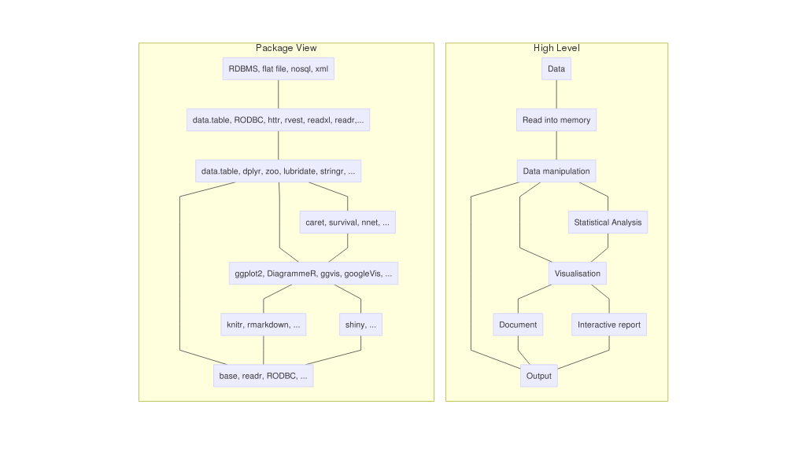

## Top 10 packages

1. data.table
2. ggplot2
3. knitr
4. shiny
5. rmarkdown
6. RODBC
7. readxl
8. stringr
9. dplyr
10. httr

I lied…

1. foreach
2. doMC
3. magrittr
4. xtable
5. devtools
6. testthat
7. DiagrammeR
8. git2r
9. rvest
10. zoo

# Installation

Back to top

Please note these instructions were tested on a Windows 8.1 clean VM from Azure on 20/07/2015 - updates to r, rstudio, packages, or the training package could cause drift between what works and what doesn't and you'll have to wing it. If you do have to wing it, let me know and I'll update my instructions!

## R

- Download latest base R exe file from [cran.rstudio.com](http://cran.rstudio.com/)
- Also download Rtools latest exe
- Install R then Rtools - if 64bit, install both 32 and 64 as it saves you hassle with other drivers

## Rstudio

- Go to [rstudio.com](http://www.rstudio.com/products/rstudio/download/)
- Select correct install file for your PC, and install

## Git

- Download latest git version from [msysgit.github.io](https://msysgit.github.io/)
- Install

## Configuration

- Open Rstudio
- Go to Tools > Global Options and set Rstudio to point at the location of your git.exe file

[figure not shown]

- Restart Rstudio
  - If you don't automatically get the Git pane (top RHS) then Create a New Project and tick the source control checkbox
- Open up command-prompt (or use the Git pane and select Shell in the extra options)
  - Run `git config --global user.name="Your name"`
  - Run `git config --global user.email="email@addre.ss"`
- Go to the Packages area (bottom RHS) and select Install. Install devtools and installr
  - This can take a while due to dependencies
  - If you encounter any packages that could not download or install you won't be able to install Rtraining successfully, but typically re-performing ths install will pick up any packages a second time around

## Rtraining

- Install Rtraining
  - This can take a while due to dependencies, as I want you to have the most commonly used packages

    ```
    r
    # Case-sensitive!
    devtools::install_github("stephlocke/Rtraining")
    ```

- Get the project from source control by going to New Project in Rstudio, selecting from version control, and pasting in the URL `https://github.com/stephlocke/Rtraining.git`

# Syntax & structure

Back to top

## Basic operators

| Action | Operator | Example |
| --- | --- | --- |
| Subtract | - | `5 - 4` = 1 |
| Add | + | `5 + 4` = 9 |
| Multiply | * | `5 * 4` = 20 |
| Divide | / | `5 / 4` = 1.25 |
| Raise to the power | ^ | `5 ^ 4` = 625 |
| Modulus | %% | `10 %% 4` = 2 |
| Absolute remainder | %/% | `9 %/% 4` = 2 |
| Basic sequence | : | `sum(1:3)` = 6 |

## Comparison operators

| Action | Operator | Example |
| --- | --- | --- |
| Less than | < | `5 < 5` = FALSE |
| Less than or equal to | <= | `5 <= 5` = TRUE |
| Greater than | > | `5 > 5` = FALSE |
| Greater than or equal to | >= | `5 >= 5` = TRUE |
| Exactly equal | == | `(0.5 - 0.3) == (0.3 - 0.1)` is FALSE, 2 == 2 is TRUE |
| Not equal | != | `(0.5 - 0.3) != (0.3 - 0.1)` is TRUE, 2 != 2 is FALSE |
| Equal | all.equal() | `all.equal(0.5 - 0.3,0.3 - 0.1)` is TRUE |

## States

| States | Representation |
| --- | --- |
| True | `TRUE` `1` |
| False | `FALSE` `0` |
| Empty | `NULL` |
| Unknown | `NA` |
| Not a number e.g. `0/0` | `NaN` |
| Infinite e.g. `1/0` | `Inf` |

## Logical operators

| Action | Operator | Example |
| --- | --- | --- |
| Not | ! | `!TRUE` is FALSE |
| And | & | `TRUE & FALSE` is FALSE, `c(TRUE,TRUE) & c(FALSE,TRUE)` is FALSE, TRUE |
| Or |  |  |
| Xor | xor() | `xor(TRUE,FALSE)` is TRUE |
| Bitwise And | && | `c(TRUE,TRUE) && c(FALSE,TRUE)` is FALSE |
| Bitwise Or |  |  |
| In | %in% | `"Red" %in% c("Blue","Red")` is TRUE |
| Not in | !( x %in% y) or Hmisc::%nin% | `"Red" %nin% c("Blue","Red")` = FALSE |

## Control constructs

| Type | Implementation | Example |
| --- | --- | --- |
| If | if(condition) {dosomething} | `if(TRUE) { 2 }` is 2 |
| If else | if(condition) {do something} else {do something different} or ifelse(condition, do something, do something else) | `if(FALSE) { 2 } else { 3 }` is 3 `ifelse(FALSE, 2, 3)` is 3 |
| For loop | for(i in seq) {dosomething} or foreach::foreach(i=1:3) %do% {something} | `foreach(i=1:3) %do% {TRUE}` is TRUE, TRUE, TRUE |
| While loop | while(condition) {do something } | `a<-0 ; while(a<3){a<-a+1} ; a` is 3 |
| Switch | switch(value, …) | `switch(2, "a", "b")` is b |
| Case | memisc::cases(…) | `cases("pi<3"=pi<3, "pi=3"=pi==3,"pi>3"=pi>3)` is pi>3 |

> NB: If you find yourself using a loop, there's probably a better, faster solution

## Assignment operators

| Action | Operator | Example |
| --- | --- | --- |
| Create / update a variable | <- | `a <- 10` |

> NB: There are others you could use, but this is the best practice

## Accessors

| Action | Operator | Example |
| --- | --- | --- |
| Use public function from package | :: | `memisc::cases()` |
| Use private function from package | ::: | `optiRum:::pounds_format()` |
| Get a component e.g a data.frame column | $ | `iris$Sepal.Length` |
| Extract a property from a class | `@` | *Won't be used in this course* |
| Refer to positions in a data.frame or vector | [ ] | `iris[5:10,1]` |
| Refer to item in a list | [[ ]] | `list(iris=iris,mtcars=mtcars)[["iris"]]` |

## Meta-operators

| Action | Operator | Example |
| --- | --- | --- |
| Comment | # | `# This is my comment` |
| Help | ? | `?data.table` |
| Identifier |  | `` irisDT[ , `:=`(CreatedDate = Sys.Date())] `` |

# Data types

Back to top

## Primitive data types

| Data type | Example |
| --- | --- |
| Integer | 1 |
| Logical | TRUE |
| Numeric | 1.1 |
| String / character | “Red” |
| Factor (enumerated string) | “Amber” or 2 in c(“Red”,“Amber”,“Green”) |
| Complex | i |
| Date | “2015-04-24” |

## Compound data types

| Data type | Info | Construction example(s) |
| --- | --- | --- |
| Vector | A 1D set of values of the same data type | c(1,“a”) , 1:3 , LETTERS |
| Matrix | A 2D set of values of the same data type | matrix(LETTERS,nrow=13, ncol=2) , rbind(1:5,2:6) |
| Array | An nD set of values of the same data type | array(LETTERS, c(13,2)) |
| Data.frame | A 2D set of values of different data types | data.frame(a=1:26, b=LETTERS) |
| List | A collection of objects of various data types | list(vector=c(1,“a”), df=data.frame(a=1:6)) |
| Classes | A class is like a formalised list and can also contain functions i.e. methods | *Won't be covered in this class* |

> NB: Most of my work uses vectors, data.tables (a souped up version of data.frames), and lists

## Useful functions relating to data types

| Function | Use |
| --- | --- |
| is.[data type] | Whether a vector is of a particular type |
| as.[data type] | Attempts to coerce a vector to a data type |
| str | Structure of an object including class/data type, dimensions |
| class | The class(es)/data type(s) an object belongs to |
| summary | Summarises an object |
| dput | Get R code that recreates an object |
| unlist | Simplify a list to a vector |
| dim | Dimensions of a data type |

# IO

Back to top

## Requirements

- suggested package: data.table
- suggested package: readr
- suggested package: readxl

## In

| Format | Functions |
| --- | --- |
| CSV | read.csv , data.table::fread , readr::read_csv |
| Excel | readxl::read_excel |
| Database | RODBC::sqlQuery , DBI::dbGetQuery |
| SPSS / SAS / Stata | haven::read_[prog] |

## Out

| Format | Functions |
| --- | --- |
| CSV | write.csv |
| Excel | openxlsx::write.xlsx |
| Database | RODBC::sqlSave , DBI::dbWriteTable |
| SPSS / SAS / Stata | foreign::write.foreign |

## Other file types

As well standard formats, there's a lot of connector packages out there, including a suite for [Hadoop](https://github.com/RevolutionAnalytics/RHadoop/wiki).

# Wrangling tables

Back to top

## Requirements

- necessary package: data.table (>=v1.9.5)
- suggested package: optiRum

## SQL

### data.table is “SQL-like”

```
DT[i, j, by]
DT[WHERE | JOIN | ORDER, SELECT | UPDATE, GROUP]
```

### data.table behaves like a database

A data.table acts like an in-memory RDBMS:

- The result of a query is a table
- Can set clustered primary keys over single or multiple columns
- Can set non-clustered secondary keys over single or multiple columns
- Can perform a wide range of relational algebra
- Can do CRUD operations
- Think in columns / sets not rows!

### data.table differences to SQL Server

There are some differences that need to be mentioned:

- A primary key can have repeat values
- No constrained foreign keys
- Joins are done by *position in key* so tblA with key A, and tblB with key C,A would join on tblA[A] and tblB[C]
- It's inherently dynamic so vectors of column names etc. can be provided to it
- DELETE doesn't exist explicitly
- It's case-sensitive

## data.table cookbook

### Single table basics

| Task | Generic syntax | Example(s)* |
| --- | --- | --- |
| CREATE | data.table(…) setDT() | `data.table(a=1:3 , b=LETTERS[1:3])` `data.table(iris)` |
| PRIMARY KEY | data.table(…,key) setkey() | `data.table(a=1:3 , b=LETTERS[1:3], key="b")` `setkey(data.table(iris),Species)` |
| SELECT basic | DT[ , .( cols )] | `irisDT[ , .(Species, Sepal.Length)]` |
| SELECT alias | DT[ , .( a=col )] | `irisDT[ , .(Species, Length=Sepal.Length)]` |
| SELECT COUNT | DT[ , .N] | `irisDT[ ,.N]` |
| SELECT COUNT DISTINCT | DT[ , uniqueN(cols)] | `irisDT[ ,uniqueN(.SD)]` |
| SELECT aggregation | DT[ , .( sum(col) , .N )] | `irisDT[ , .(Count=.N, Length=mean(Sepal.Length))]` |
| WHERE exact on primary key | DT[value] DT[value, ] | `irisDT["setosa"]` `irisDT["setosa", .(Count=.N)]` |
| WHERE | DT[condition] DT[condition, j, by] | `irisDT[Species=="setosa"]` `irisDT[Species=="setosa", .(Count=.N)]` |
| WHERE BETWEEN | DT[between(col, min, max)] DT[ col %between% c(min,max) ] | `irisDT[between(Sepal.Length, 1, 5)]` `irisDT[Sepal.Length %between% c(1,5)]` |
| WHERE LIKE | DT[like(col,pattern)] DT[ col %like% pattern ] | `irisDT[like(Species,"set")]` `irisDT[Species %like% "set"]` |
| ORDER asc. | DT[order(cols)] DT[order(cols), j, by] | `irisDT[order(Species)]` |
| ORDER desc. | DT[order(-cols)] DT[order(-cols), j, by] | `irisDT[order(-Species)]` |
| ORDER multiple | DT[order(cols)] DT[order(cols), j, by] | `irisDT[order(-Species, Petal.Width)]` |
| GROUP BY single | DT[i, j, by] | `irisDT[ ,.N, by=Species]` |
| GROUP BY multiple | DT[i, j, by] | `irisDT[ ,.N, by=.(Species,Width=Petal.Width)]` |
| TOP | head(DT, n) | `head(irisDT)` |
| HAVING | DT[i, j, by][condition] | `irisDT[ , .(Count=.N), by=Species][Count>25]` |
| Sub-queries | DT[…][…][…] | `irisDT[ , .(Sepal.Length=mean(Sepal.Length)), by=Species][Sepal.Length>6, .(Species)]` |

* Uses `irisDT <- data.table(iris)`

### CRUD

| Task | Generic syntax | Example(s)* |
| --- | --- | --- |
| INSERT | DT <- rbindlist(DT, newDT) | `irisDT<-rbindlist( irisDT, irisDT[1] )` |
| READ aka SELECT (see above) | DT[ , .( cols )] | `irisDT[ , .(Species, Sepal.Length)]` |
| UPDATE / ADD column | DT[ , a := b ] | `irisDT[ , Sepal.Area := Sepal.Width * Sepal.Length]` |
| UPDATE / ADD multiple columns | DT[ , :=(a = b, c = d) ] | `` irisDT[ , `:=`(CreatedDate = Sys.Date(), User = "Steph")] `` |
| UPDATE / ADD multiple columns by reference | DT[ , (newcols):=vals ] | `irisDT[ , c("a","b"):=.(1,2)]` |
| DELETE | DT <- DT[!condition] | `irisDT <- irisDT[!(Species=="setosa" & Petal.Length>=1.5)]` |
| DROP table | DT <- NULL | `irisDT<-NULL` |
| DROP column | DT[,col:=NULL] | `iristDT[,Species:=NULL]` |

* Uses `irisDT <- data.table(iris)`

### Metadata

| Task | Generic syntax | Example(s)* |
| --- | --- | --- |
| Structure | str(DT) | `str(irisDT)` |
| Column Names | colnames(DT) | `colnames(irisDT)` |
| Summary stats | summary(DT) | `summary(irisDT)` |
| Retrieve primary key info | key(DT) | `key(irisDT)` |
| List all data.tables | tables() | `tables()` |

* Uses `irisDT <- data.table(iris)`

### Relationships

| Task | Generic syntax | Example(s)* |
| --- | --- | --- |
| INNER JOIN | Y[X, nomatch=0] | `lookupDT[irisDT,nomatch=0]` |
| LEFT JOIN | Y[X] | `lookupDT[irisDT]` |
| FULL JOIN | merge(X, Y, all=TRUE) | `merge(irisDT, lookupDT, all=TRUE)` |
| CROSS JOIN | optiRum::CJ.dt(X,Y) | `CJ.dt(irisDT, lookupDT)` |
| UNION ALL | rbindlist( list(X,Y), fill=TRUE ) | `rbindlist( list(irisDT, lookupDT), fill=TRUE )` |
| UNION | unique( rbindlist( list(X,Y), fill=TRUE ) ) | `unique( rbindlist( list(irisDT, lookupDT), fill=TRUE ) )` |
| JOIN and AGGREGATE | Y[X, cols, by] | `lookupDT[irisDT,.(count=.N),by=Band]` |

* Uses:

```
irisDT   <- data.table(iris, key="Species")
lookupDT <- data.table(Species=c("setosa", "virginica", "Blah"), Band=c("A", "B", "A"), key="Species")
```

### Intermediate tasks

| Task | Generic syntax | Example(s)* |
| --- | --- | --- |
| SELECT dynamically | DT[ , colnames , with=FALSE] , DT[ , .SD , .SDcols=colnames | `cols<-colnames(irisDT); irisDT[ , cols, with=FALSE]` `cols<-colnames(irisDT); irisDT[ , .SD, .SDcols=colnames]` |
| GROUP BY dynamically | DT[ , …, by=colnames] | `irisDT[,.N,by=c("Species")]` |
| GROUP BY, ORDER BY group | DT[ , … , keyby] | `irisDT[,.N,keyby=Species]` |
| UPDATE / ADD column of summary stat | DT[ , a := b ] | `irisDT[ , All.SL.Mean:=mean(Sepal.Length)]` |
| UPDATE / ADD column by group | DT[ , a := b, by] | `irisDT[ , Species.SL.Mean:=mean(Sepal.Length), by=Species]` |
| TOP by group | DT[ , head(.SD), by] | `irisDT[ , head(.SD,2) , by=Species]` |
| Largest record | DT[ which.max(col) ] | `irisDT[ which.max(Sepal.Length) ]` |
| Largest record by group | DT[ , .SD[ which.max(col) ], by] | `irisDT[ , .SD[ which.max(Sepal.Length) ], by=Species]` |
| Cumulative total | DT[ , cumsum(col) ] | `irisDT[ , cumsum(Sepal.Width)]` |
| NEGATIVE SELECT | DT[ , .SD, .SDcols=-“colname”] | `irisDT[ , .SD, .SDcols=-"Species"]` |
| RANK | DT[ , frank(col) ] | `irisDT[ , frank(Sepal.Length,ties.method="first")]` |
| AGGREGATE multiple columns | DT[ , lapply(.SD, sum)] | `irisDT[ , lapply(.SD,sum), .SDcols=-"Species"]` |
| AGGREGATE multiple columns by group | DT[ , lapply(.SD, sum), by] | `irisDT[ , lapply(.SD,sum), by=Species]` |
| COUNT DISTINCT multiple columns by group | DT[ , lapply(.SD, uniqueN), by] | `irisDT[ , lapply(.SD,uniqueN), by=Species]` |
| COUNT NULL multiple columns by group | DT[ , lapply(.SD, function(x) sum(is.na(x))), by] | `irisDT[ , lapply(.SD,function(x) sum(is.na(x))), by=Species]` |
| PIVOT data - to single value column | melt(DT,…) | `melt(irisDT)` |
| PIVOT data - to aggregate | dcast(DT, a~b, function) | `dcast(melt(irisDT), Species ~ variable, sum)` |
| Convert a large data.frame or list | setDT() | `iris<-iris; setDT(iris)` |
| ROW_NUMBER | DT[ , .I] | `irisDT[ , .I]` |
| GROUP number | DT[, .GRP ,by] | `irisDT[ , .GRP, by=Species]` |

* Uses `irisDT <- data.table(iris)`

### Advanced tasks

| Task | Generic syntax | Example(s)* |
| --- | --- | --- |
| GROUP BY each new incidence of group | DT[ , cols , by=(col, rleid(col))] | `irisDT[order(Sepal.Length), .N, by=.(Species, rleid(Species))]` |
| Calculate using (previous/next) N row | DT[ , shift( cols, n)] | `irisDT[ , prev.Sepal.Length:=shift(Sepal.Length), by=Species ]` |
| ORDER underlying table | setorder() | `setorder(irisDT,Species)` |
| JOIN & GROUP by keys | X[Y, .N, by=.EACHI] | `irisDT[lookupDT, .N, by=.EACHI]` |
| TRANSPOSE data.table | transpose(DT) | `transpose(irisDT)` |
| Split string to columns | DT[, tstrsplit(charCol, pattern) ] | `irisDT[ , tstrsplit(as.character(Species),"e")]` |

* Uses:

```
irisDT   <- data.table(iris, key="Species")
lookupDT <- data.table(Species=c("setosa", "virginica", "Blah"), Band=c("A", "B", "A"), key="Species")
```

## More resources

- [data.table wiki](https://github.com/Rdatatable/data.table/wiki/Getting-started)

# Making charts

Back to top

## DISCLAIMER

This intro covers the charting package ggplot2.

The “base” charting functionality will not be covered because it's much more difficult to achieve good looking results quickly and I don't believe in that much effort for so little benefit!

## Requirements

- necessary package: ggplot2
- suggested package: RColorBrewer
- suggested package: ggthemes
- suggested package: optiRum

## ggplot2

> ggplot2 is a plotting system for R, based on the grammar of graphics, which tries to take the good parts of base and lattice graphics and none of the bad parts. It takes care of many of the fiddly details that make plotting a hassle (like drawing legends) as well as providing a powerful model of graphics that makes it easy to produce complex multi-layered graphics.

### Glossary

| Term | Explanation | Example(s) |
| --- | --- | --- |
| **plot** | A plot using the grammar of graphics | `ggplot()` |
| **aes**thetics | attributes of the chart | colour, x, y |
| mapping | relating a column in your data to an aesthetic |  |
| **stat**istical transformation | a translation of the raw data into a refined summary | `stat_density()` |
| **geom**etry | the display of aesthetics | `geom_line()`, `geom_bar()` |
| **scale** | the range of values | axes, legends |
| **coord**inate system | how geometries get laid out | `coord_flip()` |
| **facet** | a means of subsetting the chart | `facet_grid()` |
| **theme** | display properties | `theme_minimal()` |

### Constructing a chart - a step by step process

1. Create the base plot (doesn't work on it's own)

```r
library(ggplot2)

p <- ggplot(data=iris)
```

1. Add aesthetic mappings (doesn't work on it's own)

```r
p <- ggplot(data=iris, aes(x=Sepal.Width, y=Sepal.Length, colour=Species))
```

1. Add a geometry

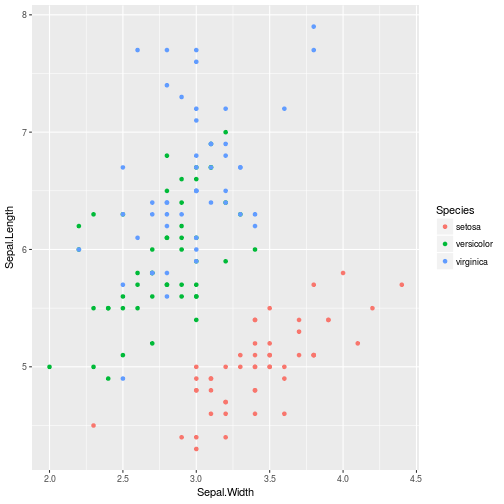

```r
p <- p + geom_point()
p
```

1. (Optional) Add a statistic

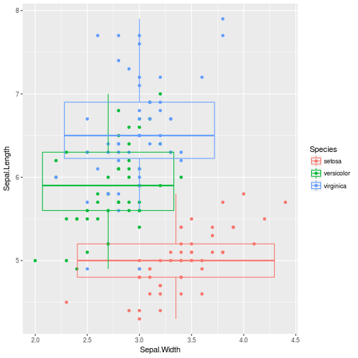

```r
p <- p + stat_boxplot(fill="transparent")
p
```

1. (Optional) Alter coordinate system

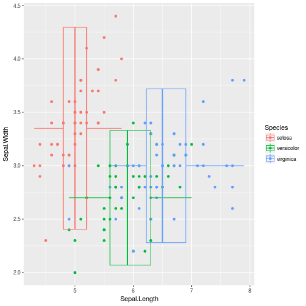

```r
p <- p + coord_flip()
p
```

1. (Optional) Facet the chart

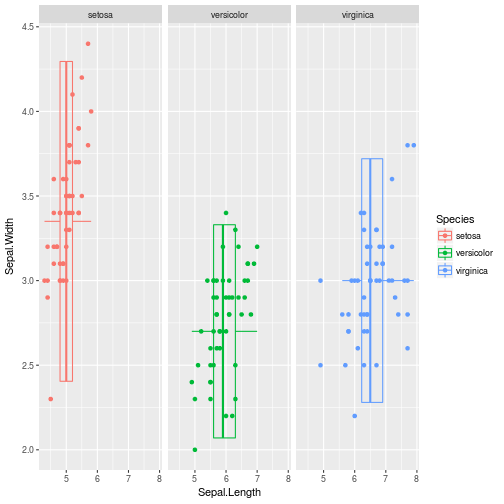

```r
p <- p + facet_grid(.~Species)
p
```

1. (Optional) Amend look and feel

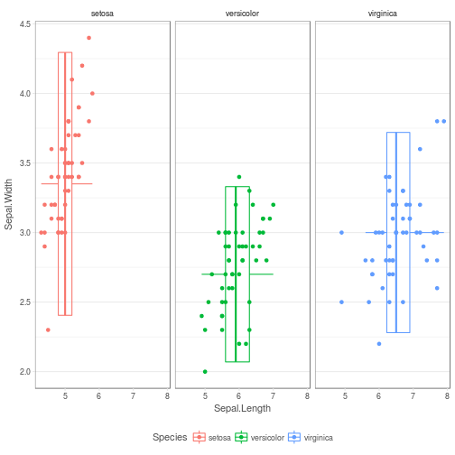

```r
p <- p + optiRum::theme_optimum()
p
```

### Constructing a chart - a one-step process

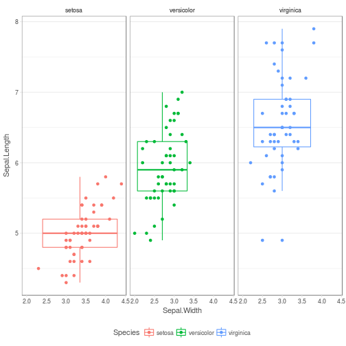

```r
ggplot(data=iris, aes(x=Sepal.Width, y=Sepal.Length, colour=Species)) +
  geom_point() +
  stat_boxplot(fill="transparent") +
  # coord_flip() + # Commented out
  facet_grid(.~Species) +
  optiRum::theme_optimum()
```

### More resources

- Hadley's documentation is top notch so check out the [ggplot2 documentation](http://docs.ggplot2.org/current/)
- View the [source code](https://github.com/hadley/ggplot2-book) for Hadley's [ggplot2 book](http://www.amazon.co.uk/ggplot2-Elegant-Graphics-Data-Analysis/dp/0387981403/ref=asap_bc?ie=UTF8)
- The online [R graphics cookbook](http://www.cookbook-r.com/Graphs/)
- A [ggplot2 cheatsheet](http://zevross.com/blog/2014/08/04/beautiful-plotting-in-r-a-ggplot2-cheatsheet-3/) blog post
- [Plot.ly library](https://plot.ly/ggplot2/)

# Making documents

Back to top

## Requirements

- necessary package: knitr
- necessary package: rmarkdown
- necessary software: [pandoc](http://johnmacfarlane.net/pandoc/installing.html)
- recommended software: [MiKTeX](http://miktex.org/)

## Using R for documents

Producing documents / documentation directly in R means that you closely interweave (knit) your analysis and R code together. This reduces rework time when you want to change or extend your code, it reduces time to produce new versions, and because it's code it's easier to apply strong software development principles to it.

Oh, and you don't need to spend hours making text boxes in powerpoint! Win ;-)

There are two languages which you can knit your r code into:

- markdown
- LaTeX (pronounced lay-tech alas)

Markdown is great for very quick generation and light (or css driven) styling and is what this section focusses on. LaTeX is excellent for producing stunning, more flexible documents.

## rmarkdown standard text

**The following text is the default text that gets created when you produce a new rmarkdown file in rstudio**

## rmarkdown standard documentation

**The following text is part of the standard documentation on rmarkdown. I pull it from [github.com/rstudio/rmarkdown](https://raw.githubusercontent.com/rstudio/rmarkdown/gh-pages/authoring_basics.md) and integrate it using knitr. It is better than I could produce and the act of integrating it gives an extra example of useful ways to build documents.**

This document provides quick references to the most commonly used R Markdown syntax. See the following articles for more in-depth treatment of all the capabilities of R Markdown:

- R Code Chunks
- Pandoc Markdown

#### Emphasis

```markdown
*italic*   **bold**

_italic_   __bold__
```

#### Headers

```markdown
# Header 1

## Header 2

### Header 3
```

#### Lists

Unordered List:

```markdown
* Item 1
* Item 2
    + Item 2a
    + Item 2b
```

Ordered List:

```markdown
1. Item 1
2. Item 2
3. Item 3
    + Item 3a
    + Item 3b
```

#### R Code Chunks

R code will be evaluated and printed

````markdown
```{r}
summary(cars$dist)
summary(cars$speed)
```
````

#### Inline R Code

```markdown
There were 50 cars studied
```

#### Links

Use a plain http address or add a link to a phrase:

```markdown
http://example.com

[linked phrase](http://example.com)
```

#### Images

Images on the web or local files in the same directory:

```markdown
![](http://example.com/logo.png)

![optional caption text](figures/img.png)
```

#### Blockquotes

```markdown
A friend once said:

> It's always better to give
> than to receive.
```

#### Plain Code Blocks

Plain code blocks are displayed in a fixed-width font but not evaulated

````markdown
```
This text is displayed verbatim / preformatted
```
````

#### Inline Code

```markdown
We defined the `add` function to
compute the sum of two numbers.
LaTeX Equations
```

#### LaTeX Equations

Inline equation:

```markdown
$equation$
```

Display equation:

```markdown
$$ equation $$
```

#### Horizontal Rule / Page Break

Three or more asterisks or dashes:

```markdown
******

------
```

#### Tables

```markdown
First Header  | Second Header
------------- | -------------
Content Cell  | Content Cell
Content Cell  | Content Cell
Reference Style Links and Images
```

#### Links

```markdown
A [linked phrase][id].
```

At the bottom of the document:

```markdown
Images
![alt text][id]
```

At the bottom of the document:

#### Manual Line Breaks

End a line with two or more spaces:

```markdown
Roses are red,
Violets are blue.
```

#### Miscellaneous

```markdown
superscript^2^

~~strikethrough~~
```

# Making reports

Back to top

## What's Shiny?

- An interactive report framework
- An R package that is available free (as is the server edition)
- Uses “modern web standards” like bootstrap under the hood
- Cross-browser/Cross-device compatibility, out of box!

## Quick example

```r
library(data.table)
library(shiny)
defaultdisplay<-list(
    width="100%", height="75%"
  )
shinyAppDir(
  system.file("examples/06_tabsets", package="shiny"),
  options = defaultdisplay
)
```

## Shiny structure

### Typical Contents

A shiny application report consists of two functions:

- `shinyServer()`
- `shinyUI()`

One says what to execute and the other states how to present it. Do all data manipulation, chart production in `shinyServer()`

### “Lite” Contents

```r
defaultdisplay<-list(width="100%", height="75%")

shinyApp(
    ui      = fluidPage(),
  , server  = function(input, output) {}
  , options = defaultdisplay
)
```

## Files

You typically split into two files:

- server.R containing `shinyServer()`
- ui.R containing `shinyUI()`

This can then be run with `runApp()`

You can do a single file example `app.R` which contains both functions but this is typically better for very short apps.

## Front-end layout

Use these just inside `shinyUI()` to produce a layout

```
##          Page Types
## 1:        basicPage
## 2:    bootstrapPage
## 3:         fillPage
## 4:        fixedPage
## 5:        fluidPage
## 6:       navbarPage
## 7: updateNavbarPage
```

## Typical Inputs

### Dates

```r
shinyApp(
  ui = fluidPage(dateInput("datePicker", "Pick a date:",
                           format="dd/mm/yy"),
                 dateRangeInput("dateRange", "Pick dates:",
                                start=Sys.Date(),
                                end=Sys.Date() ) ),
  server = function(input, output) {}
  ,options = defaultdisplay
)
```

### Values

Basic

```r
shinyApp(
  ui = fluidPage(numericInput("vals", "Insert a number:",
                              value=15, min=10)  ),
  server = function(input, output) {}
  ,options = defaultdisplay
)
```

Sliders

```r
shinyApp(
  ui = fluidPage(sliderInput("vals", "Insert a number:",
                             min=0, max=50, value=15)  ),
  server = function(input, output) {}
  ,options = defaultdisplay
)
```

### Text

A single line

```r
shinyApp(
  ui = fluidPage(textInput("char", "Insert text:")  ),
  server = function(input, output) {}
  ,options = defaultdisplay
)
```

A paragraph

```r
shinyApp(
  ui = fluidPage(tags$textarea(id="charbox", rows=3,
                               cols=40, "Default value")  ),
  server = function(input, output) {}
  ,options = defaultdisplay
)
```

### Selectors

```r
shinyApp(
  ui = fluidPage(selectInput("multiselect", "Pick favourites:",
                             c("Green","Red","Blue"),
                             multiple=TRUE)  ),
  server = function(input, output) {}
  ,options = defaultdisplay
)
```

## List of input types

```
##               Input controls
##  1:       checkboxGroupInput
##  2:            checkboxInput
##  3:                dateInput
##  4:           dateRangeInput
##  5:                fileInput
##  6:             numericInput
##  7:            passwordInput
##  8:     registerInputHandler
##  9:       removeInputHandler
## 10:             restoreInput
## 11:              selectInput
## 12:           selectizeInput
## 13:              sliderInput
## 14:            textAreaInput
## 15:                textInput
## 16: updateCheckboxGroupInput
## 17:      updateCheckboxInput
## 18:          updateDateInput
## 19:     updateDateRangeInput
## 20:       updateNumericInput
## 21:        updateSelectInput
## 22:     updateSelectizeInput
## 23:        updateSliderInput
## 24:      updateTextAreaInput
## 25:          updateTextInput
##               Input controls
```

## Typical Outputs

### Input values

```r
shinyApp(
  ui = fluidPage(textInput("char", "Insert text:") ,
                 textOutput("text")  ),
  server = function(input, output) {
    output$text <- renderText(input$char)
  }  ,options = defaultdisplay
)
```

### Basic tables

```r
shinyApp(
  ui = fluidPage(tableOutput("basictable")  ),
  server = function(input, output) {
    output$basictable <- renderTable(head(iris,5))
  }  ,options = defaultdisplay
)
```

### Interactive tables

```r
shinyApp(
  ui = fluidPage(dataTableOutput("datatable")  ),
  server = function(input, output) {
    output$datatable <- renderDataTable(head(iris,5))
  }  ,options = defaultdisplay
)
```

### Charts

```r
shinyApp(
  ui = fluidPage(plotOutput("chart")  ),
  server = function(input, output) {
    output$chart <- renderPlot(pairs(iris))
  }  ,options = defaultdisplay
)
```

## Reactivity

### Simple reactivity

- Make functions that process inputs only when they change

```r
a <- reactive({input$a})
a
```

- Use these reactive functions in downstream server items for DRY & to reduce processing effort

### An Example

```r
shinyApp(
  ui = fluidPage(textInput("char", "Insert text:") ,
                 textOutput("textA"),textOutput("textB") ),
  server = function(input, output) {
    char<-reactive({rep(input$char,5)})
    output$textA <- renderText(paste(char(),collapse="+"))
    output$textB <- renderText(paste(char(),collapse="-"))
  }
  ,options = defaultdisplay
)
```

## Styling

### shinythemes

- Get a different look and feel with the package `shinythemes`
- Uses a number of bootstrap based themes
- Good-looking quickly, but of course not company branded
- View themes at [bootswatch.com](http://bootswatch.com/)

### CSS

- Shiny outputs html so you can write CSS that works with it
- Full list of CSS items doesn't exist, use F12 on chrome or check out selectorgadget via `rvest`
- Simple stuff like body, h1 will all work

### shinydashboards

- Makers of shiny working on a framework: [Shiny Dashboard](http://rstudio.github.io/shinydashboard/)
- A new dashboarding framework - still immature but useful
- Excellent walkthrough on [Data Driven Security](http://datadrivensecurity.info/blog/posts/2015/Jan/building-security-dashboards-with-r-and-shiny-shinydashboard/)

## Infrastructure

### Ad-hoc shiny

- Rstudio (easiest) or just run directly
- Use `shiny::runApp()`
- Great for “expert” use

### Cloud

- [shinyApps.io](https://www.shinyapps.io/)
- Deploy with `shinyApps` package
- Free for light use
- Extra management features at increased costs
- Great for hands-off management

### Central server

- shiny-server
- Runs on linux
- Free community edition
- Extra management features & LDAP auth in Pro Edition (but can roll your own)
- Great for sensitive and/or db-driven appplications

### Recommended reading

- [Shiny site](http://shiny.rstudio.com/)
- A bit outdated but: [Web Application Development with R Using Shiny](http://www.amazon.co.uk/gp/product/B00G395OOY)
- [Reactivity Overview](http://shiny.rstudio.com/articles/reactivity-overview.html)
- [shiny for teaching maths](https://github.com/hadley/reactive-docs)
- [Show me Shiny!](http://www.showmeshiny.com/)
- [Deploying shiny apps](http://shiny.rstudio.com/tutorial/lesson7/)

# LaTeX

Back to top

## About LaTeX

> Pronunciation: lay-tech

LaTeX is an open source markup language with a typesetting engine. It's been around since the 70s and generally makes awesome documents.

LaTeX is designed to work stand-alone, or integrate with other languages. It's particularly good with R.

It works in the way rmarkdown does with knitr, but allows for more sophisticated document styling.

## Why LaTeX?

- Seamless integration between code and content
- Fantastic looking documentation
- Works on all operating systems and has a number of cloud/internet hosted services
- Can use markdown and append LaTeX style
- Use for more polished presentations without having to go into PowerPoint

## Get LaTeX

- Online: [Overleaf.com](http://overleaf.com)
- Windows: [proTeXt](http://www.tug.org/protext/)
- Mac: [MacTex](http://www.tug.org/mactex/)
- Linux: `sudo apt-get texlive`

Once you have a LaTeX installation, you can write LaTeX in Rstudio.

In Rstudio, select the File type “R Sweave” which saves as a .Rnw file.

## Learn LaTeX

LaTeX is a very deep language, so no attempt is made to teach you here.

One of the easiest ways of getting started with LaTeX (generally) is to pick one of the examples / templates on overleaf.com and play with it.

For using R and LaTeX, you can use the minimal examples on [yihui.name/knitr](http://yihui.name/knitr/demo/minimal/) to get started.

See the [LaTeX wikibook](http://en.wikibooks.org/wiki/LaTeX) for lots of info about LaTeX.

# Source control

Back to top

[figure not shown]

> SOURCE CONTROL IS FOR ALL THE THINGS

## Fundamentals

Source control is important because it provides:

- a backup system for your code
- a means of tracking *why* you made changes
- a way of sharing code
- a system for multiple people to work safely
- another potential way to deploy code manually
- options for automated testing and deployment
- audit trails

There are two types of source control systems:

- centralised
- distributed

Centralised means that there is a single storage location and to work on a file it must be exclusively checked out. Distributed systems involve taking copies of the code base, making changes, and pushing these back to primary storage location.

Both have their own disadvantages but since with distributed source control you never get the situation where someone's left a file checked out as they go on holiday and no-one else can use it, I'm a big fan of distributed source control systems.

## Git

Git is a distributed source control system.

It integrates neatly into Rstudio, making it easy to source control your analysis.

### The git conceptual model ([\@cthydng](https://twitter.com/cthydng/status/575483540202106880))

[figure not shown]

### Git glossary

- Repository: Your project and it's history
- Remote: The (TFS/GitHub/VSO etc) server
- Clone:Take a linked copy of a repository
- Fork: Take an unlinked copy of a repository
- Pull: Update your copy of a repository
- Add: Include a file in a change
- Commit: Make the latest state of all the added files the new default state
- Push: Update the central copy of the repository with your commits

There are more terms. For a friendly glossary see [Github's git glossary](https://help.github.com/articles/github-glossary/), and for an extensive, technical glossary see the official [Git glossary](https://www.kernel.org/pub/software/scm/git/docs/gitglossary.html)

## git2r

The package `git2r` supports a source control workflow directly within R. This means you can continue to use Rstudio for even complex git tasks. And of course there's always the shell option in Rstudio.

For a handy Git cheatsheet, check out this [GitHub one](https://training.github.com/kit/downloads/github-git-cheat-sheet.pdf).

The [git2r documentation](https://github.com/ropensci/git2r) is pretty good. It's easier though to use once you've been utilising the Rstudio GUI for a bit, and dabbling with the command line.

# Package development

Back to top

## Requirements

- necessary package: devtools
- suggested package: testthat

## What's a package?

A package is a collection of functionality designed to achieve one or more purposes. Commonly it is a bundle of functions that help tackle a certain type of analysis.

Packages are great ways to modularise your code and create standardised ways of doing specific tasks in your organisation, like charts (`optiRum::theme_optimum()`).

## The package development Bible

There is an [R foundation guide to writing packages](http://cran.r-project.org/doc/manuals/r-release/R-exts.html). I don't recommend you start with that! It is however what any package that you submit to the central repository of R packages (CRAN) will be held against - so if you'd like to get a package on CRAN you will need to read this.

The better, more accessible book [R packages](http://r-pkgs.had.co.nz/) is by Hadley Wickham and will cover things in a lot of depth but is more accesable and has exercises.

For quick learning abotu devtools you can check out [the cheatsheet](http://www.rstudio.com/wp-content/uploads/2015/03/devtools-cheatsheet.pdf)

## How do you build a package?

The easiest way to build a good quality package is to use the package devtools. This is a package designed specifically to make life easier for package developers.

Here is my typical workflow:

```r
library(devtools)
pkg<-"newPackage"
create(pkg)

# Open the project!

library(devtools)

# Add unit test framework
add_test_infrastructure()

# Add CI framework
add_travis()

# Add folder for macro-level help files
use_vignette()

# Add file for providing info about your package
use_package_doc()

# Add a file for storing comments about the release if submitting to CRAN
use_cran_comments()

# Create various useful files
file.create("README.md")
file.create("NEWS")

# Set git up
library(git2r)
init(".")
```

Once I have this skeleton I fill in the various bits of info about my package in DESCRIPTION, README, R/package.R, and so forth.

After I've done some basic hygiene, I can start building my R functions and associated tests.

## Writing quality functions

1. Plan it out
2. Write the documentation first
3. Keep testing foremost in your mind - ideally, write unit tests first
4. Choose sensible defaults for paramaters
5. (Without strong reason) make your function return an object that has to be specifically assigned to the global environment
6. Add validation of inputs and error handling
7. Avoid loops
8. Make dependencies obvious
9. Consider how you will be able to test the function
10. Use the ellipsis (`...`) argument to pass values through to optional components in functions

```r
#' A function quick description
#'
#' A more detailed description that can span multiple lines
#' for readability. Covers concepts, typical usages etc.
#'
#' @param  param1 Info about param1 e.g. data type, guidance
#' @param  param2 Info about param1 e.g. data type, guidance
#' @param  ...    Additional values to pass to x, y, z
#'
#' @return returnDT Info about what is returned by the function
#'
#' @keywords words allowing search
#' @family ifPartOfABundle
#'
#' @examples
#' # Sample code that illustrates usage
#'
#' @export

myFuncName<- function(param1, param2="Blah", ...){
stopifnot(param1>0, is.character(param2))

# Function code routinely commented with WHY or
# explanations of complex HOW (but consider
# breaking these up / simplifying)
}
```

## Verification process

Let's make sure your code is all working (assumes you've got unit tests)

```r
library(devtools)

# Build help files
document()

# Run unit tests
test()

# Check against CRAN standards
check()
```

Each of these steps could identify things to fix. It's great to get rid of as many ERRORs, WARNINGs, and NOTEs as possible.

## Publishing your package

There are a number of locations but I'll cover two:

1. CRAN: The central repository of packages, this is ensures a minimum level of quality. It does however have some weird rules (like Title Case demands) and one or two of the gate-keepers aren't very patient with people. It's great to do, but be prepared for rework and some comments that could make you wince.
2. GitHub: GitHub is becoming more and more indexed and well utilised asa location for R packages.

My personal recommendations are to use GitHub as your active development environment, so that people can download the latest version, and periodically attempt to release to CRAN. This helps push up your package quality and makes your code more widely available.

# Testing

Back to top

## Requirements

- necessary package: testthat

## What's unit testing?

Unit testing is the technique of writing tests that assess low-level functionality against requirements.

## Why should I unit test - I do charts and databases?

In reports, databases, and code we typically encode business rules, conventions, and our own conventions. Bringing these into reusable functions means less code reproduction, no variances between team members, and lower time to change.

All of these are verifiably correct and so can be tested. Therefore, why test them manually, or why risk someone “tweaking” the code and changing the rules without people knowing? Your unit tests save you time over the long run, and protect against unexpected behaviour changes.

Reconciliations can also be done inside your unit tests. If you have “canonical answers”, you can test new transformations against these to ensure you're consistent.

## How to unit test?

I'm not a developer so this may be the wrong approach but here are the scenarios I write tests for:

1. A single set of values that represent “normal” and expect this matches a correct answer
2. A dataset that represents “normal” and expecting this to match correct answers
3. Various permutations of bad input values and expect errors (ideally specific error messages)
4. Edge cases that cover extreme values or boundaries for any inequalities or conditions
5. Any bugs or compatibility issues

Also, if you're struggling to test because it's got really complex inputs, outputs, or intermediate calculations, consider breaking up the code and rewriting. It's more likely that things are going to go wrong and you won't know if something is particularly complex.

## How to unit test in R?

Let's build a sample function:

```r
myfunc<-function(a=1,b=2,c="blah"){
stopifnot(is.numeric(a), is.numeric(b),
            is.character(c))
d<-if(a<0){
          a*b
          }else{
          a/b
          }

e<-paste0(c,d)

return(e)
}
```

Let's write some tests (in a file `tests/testthat/test-myfunc.r`)

```r
# Add a high-level name for group of tests, typically the function name
context("myfunc")

# Simplest test
test_that("Defaults return expected result",{
  result<-myfunc()
  check<-"blah0.5"
  expect_equal(result,check)
})

# Vector test
test_that("Basic vectorisation works",{
  result<-myfunc(a=c(1,1),b=c(2,2), c=c("blah","blah"))
  check<-c("blah0.5","blah0.5")
  expect_equal(result,check)
})

# Non-uniform vectorisation test
test_that("Complex vectorisation works",{
  result<-myfunc(a=c(1,1),b=c(2,2))
  check<-c("blah0.5","blah0.5")
  expect_equal(result,check)
})

# Test a different condition
test_that("Negative a values result in multiplication",{
  result<-myfunc(a=c(-1,-2),b=c(2,2))
  check<-c("blah-2","blah-4")
  expect_equal(result,check)
})

# Test a different condition
test_that("a=0 values result in 0",{
  result<-myfunc(a=0)
  check<-c("blah0")
  expect_equal(result,check)
})

# Test some duff inputs
test_that("errors expectedly",{
  expect_error(myfunc(a="0"))
  expect_error(myfunc(b="0"))
  expect_error(myfunc(c=0))
})
```

There are a lot more expectation functions you can use and you can make your own.

# Continuous integration with Travis-CI

Back to top

With [excellent guidance](http://r-pkgs.had.co.nz/) and [tooling](http://cran.r-project.org/web/packages/devtools/) on making R packages, it's becoming really easy to make a package to hold your R functionality. This has a host of benefits, not least source control (via GitHub) and unit testing (via the [`testthat`](http://cran.r-project.org/web/packages/testthat/) package). Once you have a package and unit tests, a great way of making sure that as you change things you don't break them is to perform [Continuous integration](http://www.thoughtworks.com/continuous-integration).

What this means is that **every** time you make a change, your package is built and thoroughly checked for any issues. If issues are found the “build's broke” and you have to fix it ASAP.

The easiest, cheapest, and fastest way of setting up continuous integration for R stuff is to use [Travis-CI](https://travis-ci.com/), which is free if you use [GitHub](http://github.com) as a remote server for your code. *NB - it doesn't have to be your only remote server*

## Account setup

The first thing that needs doing is setting up your accounts and turning on CI for your repositories. The website is pretty good so I won't go into a lot of detail, but the process is:

1. sign up for a Travis-CI account
2. link it to your GitHub account
3. say which repositories you want to do CI on
4. add config to your repositories

Additionally, whilst we're doing this we should be awesome and set up test coverage checks as well. The process is really similar, but for [coveralls.io](https://coveralls.io/) and we only need the one set of config details in our package.

## The config file

Then you add a really simple file into the root of your project called `.travis.yml`.

This should contain, at minimum, the following:

```
language: r
sudo: required

r_github_packages:
 - jimhester/covr

after_success:
  - Rscript -e 'library(covr);coveralls()'
```

*NB - be careful with the indentation, YAML is very sensitive!*

This is the latest set of values that work as it takes into account the recent support for R, the ability to reference github packages, and also Travis' move towards docker containers which don't accept sudo commands.

Once you've flipped the switch on Travis and Coveralls, every push to GitHub will trigger Travis. Travis will basically build a server with all the requirements needed to run R and build R packages. It'll then install all your package's dependencies, check the package for minimum quality standards and also run your testthat tests. Once this is done the final bit tests your code coverage and passes the results to Coverall.

## Badge of honour

Great, so you've checked the sites and it's working but you should show the world it's working! You can get some some snippets of code from each of the sites that you can paste into your README file. These stay up to date with the latest results so that you (and everyone else) can see the status of your package.

# Installing Rstudio

Back to top

## Server creation

Azure portal, using gallery creation for VM

[figure not shown]

## Configuring the VM

1. Get [PuTTY](http://the.earth.li/%7Esgtatham/putty/latest/x86/putty.exe)
2. Connect to your VM via the public IP

[figure not shown]

3. Use the login details in the creation wizard. *The password won't look like you're typing*
4. Run `sudo apt-get update` to get the package repository metadata
5. Run `sudo apt-get install r-base` to get R. *Will have lots of extra associated packages - select Y when prompted*
6. Follow the [installation instructions](https://support.rstudio.com/hc/en-us/articles/200552306-Getting-Started), using the [latest file](http://www.rstudio.com/products/rstudio/download-server/)
   - Run `sudo apt-get install gdebi-core` to enable processing of rstudio installation package
   - Run `sudo apt-get install libapparmor1` if using ubuntu
   - Run (latest version of) `wget http://download2.rstudio.org/rstudio-server-0.98.1103-amd64.deb`
   - Run (latest version of) `sudo gdebi rstudio-server-0.98.1103-amd64.deb` ## Configuring port (away from 8787) and allowing on Azure
7. Change rstudio to run on port 80 by amending port in conf file `sudo nano /etc/rstudio/rserver.conf`
8. Restart rstudio to apply port change `sudo rstudio-server restart`
9. Add port 80 to Azure endpoints for the VM

[figure not shown]

# Installing shiny-server

Back to top

## Server creation

Azure portal, using gallery creation for VM

[figure not shown]

## Configuring the VM

1. Get [PuTTY](http://the.earth.li/%7Esgtatham/putty/latest/x86/putty.exe)
2. Connect to your VM via the public IP

[figure not shown]

3. Use the login details in the creation wizard. *The password won't look like you're typing*
4. Run `sudo apt-get update` to get the package repository metadata
5. Run `sudo apt-get install r-base` to get R. *Will have lots of extra associated packages - select Y when prompted*
6. Follow the [installation instructions](http://rstudio.github.io/shiny-server/latest/), using the [latest file](http://www.rstudio.com/products/shiny/download-server/)
   - Run `sudo su - -c "R -e \"install.packages('shiny', repos='http://cran.rstudio.com/')\""` to install shiny in R
   - Run `sudo apt-get install gdebi-core` to enable processing of shiny-server installation package
   - Run (latest version of) `wget http://download3.rstudio.org/ubuntu-12.04/x86_64/shiny-server-1.3.0.403-amd64.deb`
   - Run (latest version of) `sudo gdebi shiny-server-1.3.0.403-amd64.deb`

## Configuring port (away from 3838) and allowing on Azure

1. Change shiny-server to run on port 80 by amending port in conf file `sudo nano /etc/shiny-server/shiny-server.conf`
2. Restart shiny-server to apply port change `sudo restart shiny-server`
3. Add port 80 to Azure endpoints for the VM

[figure not shown]